# Chapter 5

shinya suzuki

2016年11月22日

# Chapter5 GLMの尤度比検定と検定の非対称性

ここでは`尤度比検定`に着目する. 尤度比検定では逸脱度の差で, ネストしたモデルを検定できる.

検定とモデル選択の枠組みは異なるが, 最尤法でパラメータを推定するところまでは一緒である.

## 尤度比検定の例題：逸脱度の差を調べる

なぜ逸脱度を使うかというと, 逸脱度では対数尤度を使う, つまり尤度に直したときには比として計算できるため.

$$\Delta D_{1,2}=-2(\log L_1^* - \log L_2^*)$$

尤度比検定では帰無仮説においたモデルから, 対象の 逸脱度をみることでその差がデータのバラつきから 生じるものなのかそれとも仮説が間違っているのかを考える.

検定なのでタイプIエラーとタイプ２エラーがあるが, 多くの場合には検出力検定, つまりどの程度の差を検出するかを調整しないので, タイプ１エラーに着目した検定となる。 このようにタイプ１しか気にしないことを指して`検定の非対称性`と呼んでいる.

あまり, 詳しいことは書かれていないけど, とりあえずパラメトリックブートストラップ法による 逸脱度の差の分布を計算してみる.

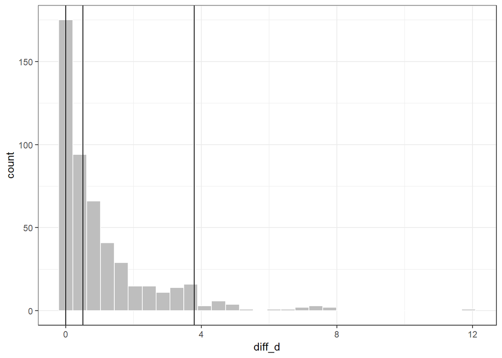

```r
generate_sample <- (function() {
    LAMBDA   <- 2
    NSIZE    <- 50
    random_x <- rnorm (NSIZE)
    function () {
        data_frame (
            y = rpois (NSIZE, LAMBDA),
            x = random_x
        )
    }
})()
formulas <-
    list (
        'x'   = "y ~ x",
        'fix' = "y ~ 1"
    )
a_sim <- function (dummy) {
    obs             <- generate_sample()
    diff_deviance  <-
        formulas %>%
        lapply(glm, data=obs, family=poisson) %>%
        lapply(deviance) %>%
        flatten_dbl %>%
        diff
    diff_deviance
}
NSIM <- 500
res  <-
    lapply (1:NSIM, a_sim) %>%
    flatten_dbl()
data_frame (diff_d = res) %>%
    ggplot(aes(diff_d)) +
    geom_histogram(colour = "white", fill="grey") +
    geom_vline (xintercept=quantile(res, c (.05, .50, .95)))+
    theme_bw()
```